# Classification

Daria Ivanushenko

6/9/2021

## **Data Exploration**

Data set used for this project was taken from the [dataset repository](http://archive.ics.uci.edu/ml/datasets/Census+Income). It describes income depending on different demographical characteristics. Main goal of the analysis is to predict income taking into account their age, country of origin, eduaction and etc.

**Columns:**

- **age**: the age of an individual Integer greater than 0
- **workclass**: a general term to represent the employment status of an individual Private, Self-emp-not-inc, Self-emp-inc, Federal-gov, Local-gov, State-gov, Without-pay, Never-worked.
- **fnlwgt**: this is the number of people the census believes the entry represents. Integer greater than 0
- **education**: the highest level of education achieved by an individual. Bachelors, Some-college, 11th, HS-grad, Prof-school, Assoc-acdm, Assoc-voc, 9th, 7th-8th, 12th, Masters, 1st-4th, 10th, Doctorate, 5th-6th, Preschool.
- **education-num**: the highest level of education achieved in numerical form. Integer greater than 0
- **marital-status**: marital status of an individual. Married-civ-spouse corresponds to a civilian spouse while Married-AF-spouse is a spouse in the Armed Forces. Married-civ-spouse, Divorced, Never-married, Separated, Widowed, Married-spouse-absent, Married-AF-spouse.
- **occupation**: the general type of occupation of an individual Tech-support, Craft-repair, Other-service, Sales, Exec-managerial, Prof-specialty, Handlers-cleaners, Machine-op-inspct, Adm-clerical, Farming-fishing, Transport-moving, Priv-house-serv, Protective-serv, Armed-Forces.
- **relationship**: represents what this individual is relative to others. For example an individual could be a Husband. Each entry only has one relationship attribute and is somewhat redundant with marital status. We might not make use of this attribute at all Wife, Own-child, Husband, Not-in-family, Other-relative, Unmarried.
- **race**: Descriptions of an individual’s race White, Asian-Pac-Islander, Amer-Indian-Eskimo, Other, Black.
- **sex**: the biological sex of the individual Male, female
- **capital-gain**: capital gains for an individual Integer greater than or equal to 0
- **capital-loss**: capital loss for an individual Integer greater than or equal to 0
- **hours-per-week**: the hours an individual has reported to work per week continuous
- **native-country**: country of origin for an individual United-States, Cambodia, England, Puerto-Rico, Canada, Germany, Outlying-US(Guam-USVI-etc), India, Japan, Greece, South, China, Cuba, Iran, Honduras, Philippines, Italy, Poland, Jamaica, Vietnam, Mexico, Portugal, Ireland, France, Dominican-Republic, Laos, Ecuador, Taiwan, Haiti, Columbia, Hungary, Guatemala, Nicaragua, Scotland, Thailand, Yugoslavia, El-Salvador, Trinadad&Tobago, Peru, Hong, Holand-Netherlands.
- **income_bracket**: whether or not an individual makes more than $50,000 annually. <= 50K, >50K

```r
library(readr)
library(dplyr)
setwd("C:\\Users\\daria\\OneDrive\\Desktop\\datasets\\data for R project")

# loading data sets for Argentina, Peru and Uruguay
data1 = read.csv("income.csv", header = TRUE, dec = ".")
```

Dataset has 48842 observations and 15 variables.

```r
library(skimr)

dim(data1)
```

```
## [1] 48842    15
```

```r
colnames(data1)
```

```
##  [1] "age"            "workclass"      "fnlwgt"         "education"
##  [5] "education_num"  "marital_status" "occupation"     "relationship"
##  [9] "race"           "gender"         "capital_gain"   "capital_loss"
## [13] "hours_per_week" "native_country" "income_bracket"
```

```r
summary(data1)
```

```
##       age         workclass             fnlwgt         education
##  Min.   :17.00   Length:48842       Min.   :  12285   Length:48842
##  1st Qu.:28.00   Class :character   1st Qu.: 117551   Class :character
##  Median :37.00   Mode  :character   Median : 178145   Mode  :character
##  Mean   :38.64                      Mean   : 189664
##  3rd Qu.:48.00                      3rd Qu.: 237642
##  Max.   :90.00                      Max.   :1490400
##  education_num   marital_status      occupation        relationship
##  Min.   : 1.00   Length:48842       Length:48842       Length:48842
##  1st Qu.: 9.00   Class :character   Class :character   Class :character
##  Median :10.00   Mode  :character   Mode  :character   Mode  :character
##  Mean   :10.08
##  3rd Qu.:12.00
##  Max.   :16.00
##      race              gender           capital_gain    capital_loss
##  Length:48842       Length:48842       Min.   :    0   Min.   :   0.0
##  Class :character   Class :character   1st Qu.:    0   1st Qu.:   0.0
##  Mode  :character   Mode  :character   Median :    0   Median :   0.0
##                                        Mean   : 1079   Mean   :  87.5
##                                        3rd Qu.:    0   3rd Qu.:   0.0
##                                        Max.   :99999   Max.   :4356.0
##  hours_per_week  native_country     income_bracket
##  Min.   : 1.00   Length:48842       Length:48842
##  1st Qu.:40.00   Class :character   Class :character
##  Median :40.00   Mode  :character   Mode  :character
##  Mean   :40.42
##  3rd Qu.:45.00
##  Max.   :99.00
```

```r
skim(data1) # we decided also to present followign fucntion as it gives great summery for dataset describing types of variables, missing values and some basic statistics
```

Data summary

| Name | data1 |
| --- | --- |
| Number of rows | 48842 |
| Number of columns | 15 |
| _______________________ |  |
| Column type frequency: |  |
| character | 9 |
| numeric | 6 |
| ________________________ |  |
| Group variables | None |

**Variable type: character**

| skim_variable | n_missing | complete_rate | min | max | empty | n_unique | whitespace |
| --- | --- | --- | --- | --- | --- | --- | --- |
| workclass | 0 | 1 | 1 | 16 | 0 | 9 | 0 |
| education | 0 | 1 | 3 | 12 | 0 | 16 | 0 |
| marital_status | 0 | 1 | 7 | 21 | 0 | 7 | 0 |
| occupation | 0 | 1 | 1 | 17 | 0 | 15 | 0 |
| relationship | 0 | 1 | 4 | 14 | 0 | 6 | 0 |
| race | 0 | 1 | 5 | 18 | 0 | 5 | 0 |
| gender | 0 | 1 | 4 | 6 | 0 | 2 | 0 |
| native_country | 0 | 1 | 1 | 26 | 0 | 42 | 0 |
| income_bracket | 0 | 1 | 4 | 6 | 0 | 4 | 0 |

**Variable type: numeric**

| skim_variable | n_missing | complete_rate | mean | sd | p0 | p25 | p50 | p75 | p100 | hist |
| --- | --- | --- | --- | --- | --- | --- | --- | --- | --- | --- |
| age | 0 | 1 | 38.64 | 13.71 | 17 | 28.0 | 37.0 | 48 | 90 | ▇▇▅▂▁ |
| fnlwgt | 0 | 1 | 189664.13 | 105604.03 | 12285 | 117550.5 | 178144.5 | 237642 | 1490400 | ▇▁▁▁▁ |
| education_num | 0 | 1 | 10.08 | 2.57 | 1 | 9.0 | 10.0 | 12 | 16 | ▁▁▇▃▁ |
| capital_gain | 0 | 1 | 1079.07 | 7452.02 | 0 | 0.0 | 0.0 | 0 | 99999 | ▇▁▁▁▁ |
| capital_loss | 0 | 1 | 87.50 | 403.00 | 0 | 0.0 | 0.0 | 0 | 4356 | ▇▁▁▁▁ |
| hours_per_week | 0 | 1 | 40.42 | 12.39 | 1 | 40.0 | 40.0 | 45 | 99 | ▁▇▃▁▁ |

```r
# Missing data
colSums(is.na(data1))
```

```
##            age      workclass         fnlwgt      education  education_num
##              0              0              0              0              0
## marital_status     occupation   relationship           race         gender
##              0              0              0              0              0
##   capital_gain   capital_loss hours_per_week native_country income_bracket
##              0              0              0              0              0
```

```r
library(stringr)
library(ggplot2)
# counts for different income groups
data1 %>% count(income_bracket)
```

```
##   income_bracket     n
## 1          <=50K 24720
## 2         <=50K. 12435
## 3           >50K  7841
## 4          >50K.  3846
```

```r
# minimum and maximum age
min(data1$age)
```

```
## [1] 17
```

```r
max(data1$age)
```

```
## [1] 90
```

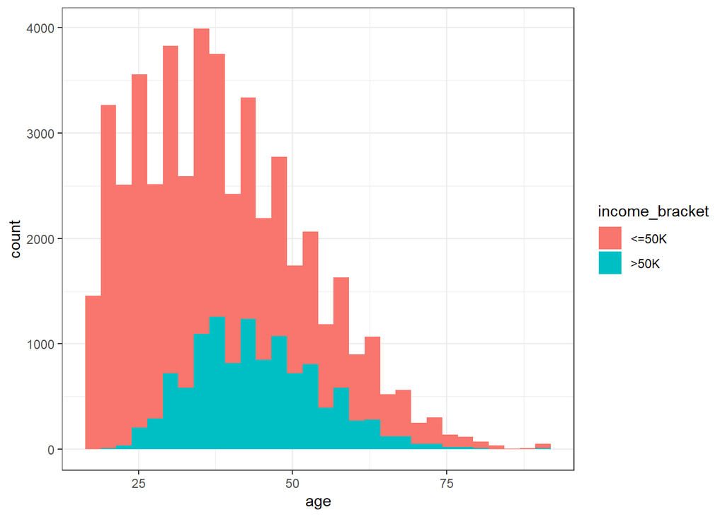

```r
# plots
data1 %>%
  mutate(income_bracket = str_replace(income_bracket, '\\.', '')) %>%
           ggplot(aes(x = age, fill = income_bracket)) + geom_histogram() + theme_bw()
```

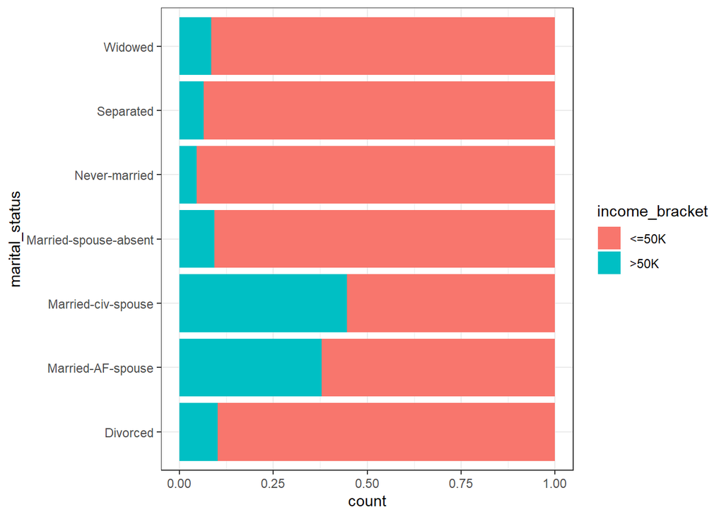

```r
data1 %>%
  mutate(income_bracket = str_replace(income_bracket, '\\.', '')) %>%
  ggplot(aes(x = marital_status, fill = income_bracket)) + geom_bar(position = "fill") + theme_bw() + coord_flip()
```

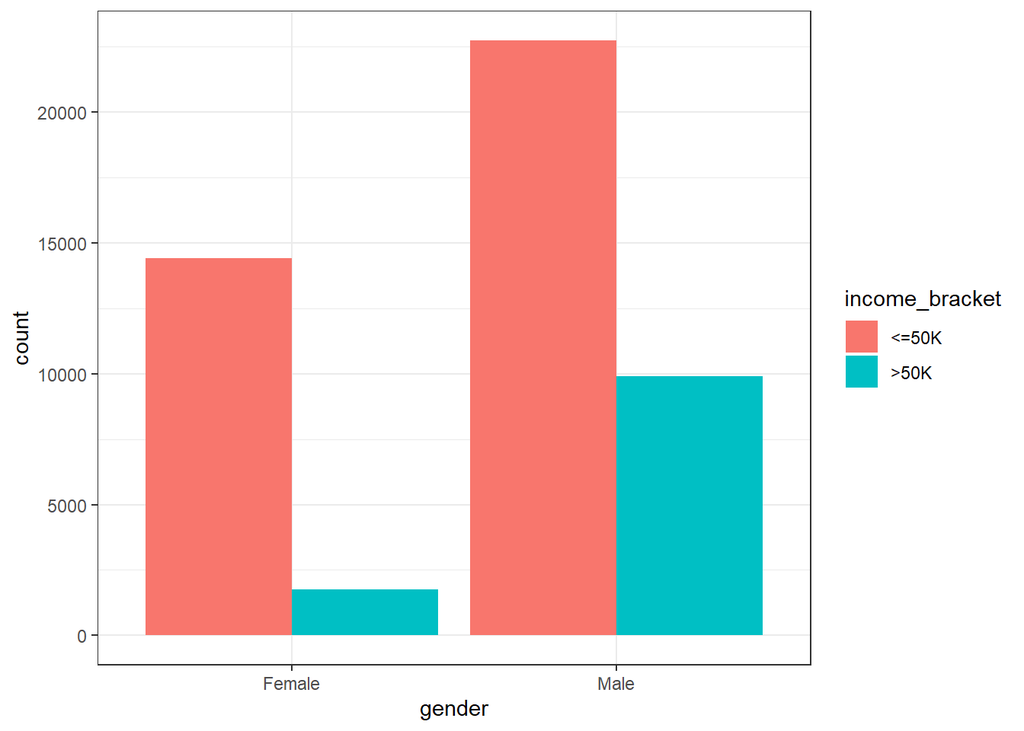

```r
data1 %>%
  mutate(income_bracket = str_replace(income_bracket, '\\.', '')) %>%
  ggplot(aes(x = gender, fill = income_bracket)) + geom_bar(position="dodge") + theme_bw()
```

In our data male groups is more represented than female. We have more male respondents with income higher than 50K comparing to female group.

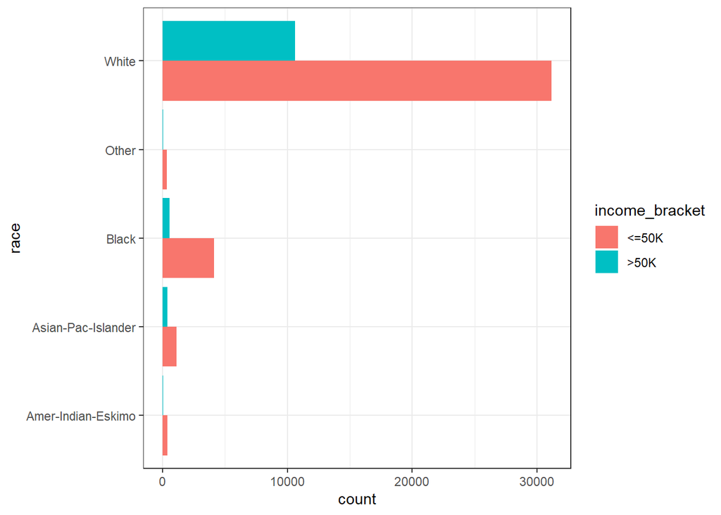

```r
data1 %>%
  mutate(income_bracket = str_replace(income_bracket, '\\.', '')) %>%
  ggplot(aes(x = race, fill = income_bracket)) + geom_bar(position="dodge") + theme_bw()+
  coord_flip()
```

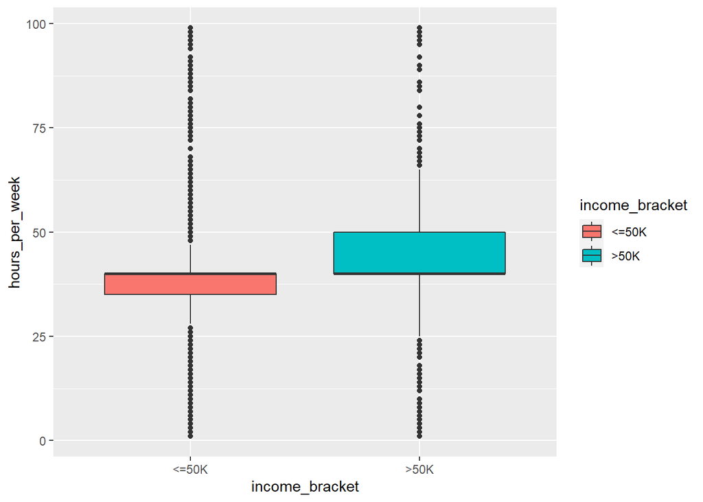

```r
data1 %>%
  mutate(income_bracket = str_replace(income_bracket, '\\.', '')) %>%
  ggplot(aes(x = income_bracket, y = hours_per_week, fill = income_bracket)) + geom_boxplot()
```

On the graphed it is illustrated that group which has income 50K or more works more hours during the week comparing to group which has less than 50K.

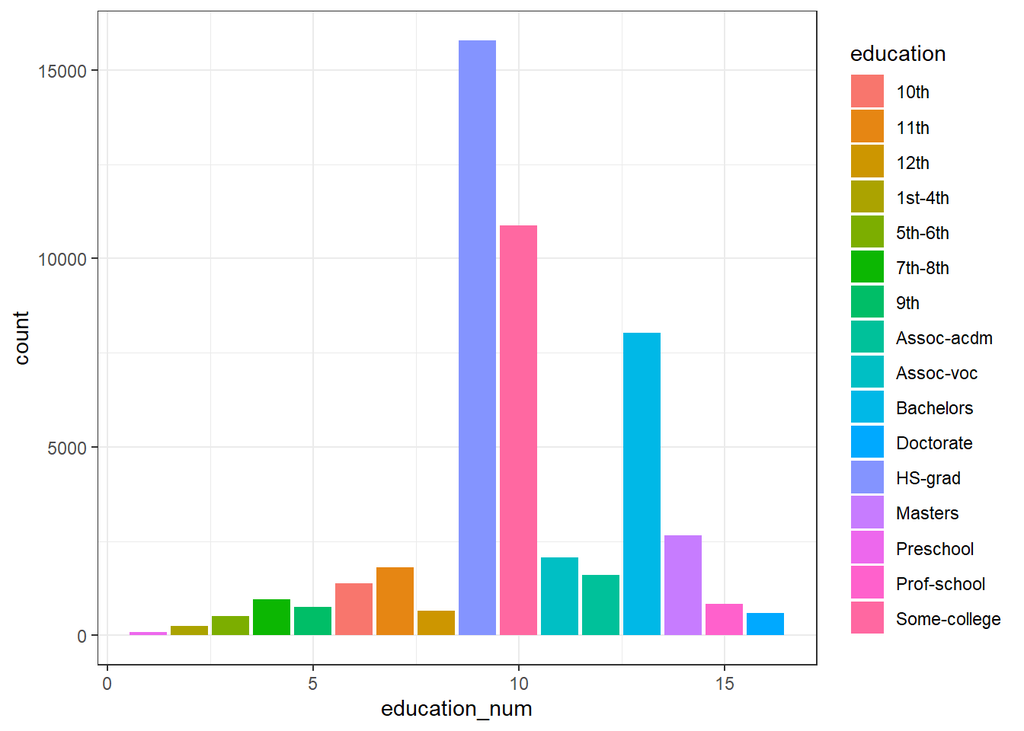

```r
ggplot(data = data1) +
  aes(x=education_num, fill=education) +
  geom_bar() +
  theme_bw()
```

From the histogram for years of schooling variable we can notice that the most frequent value is 9 years which corresponds to high school graduation. We do not see any skewness on the graph, so we can conclude that distribution of years of schooling is rather symmetrical. The maximum value is 16 years and minimum value is 1 year of schooling.

```r
#counts for differnt workclass groups. We noticed "?" value in workclass variable.
data1 %>% count(workclass)
```

```
##          workclass     n
## 1                ?  2799
## 2      Federal-gov  1432
## 3        Local-gov  3136
## 4     Never-worked    10
## 5          Private 33906
## 6     Self-emp-inc  1695
## 7 Self-emp-not-inc  3862
## 8        State-gov  1981
## 9      Without-pay    21
```

fnlwgt will be excluded in the following step of data preprocessing beacause it’s just a weight calculated based on demographical factors already included in the dataset such as gender, nationality etc.

```r
# Education (type and number of years)
count(data1, education)
```

```
##       education     n
## 1          10th  1389
## 2          11th  1812
## 3          12th   657
## 4       1st-4th   247
## 5       5th-6th   509
## 6       7th-8th   955
## 7           9th   756
## 8    Assoc-acdm  1601
## 9     Assoc-voc  2061
## 10    Bachelors  8025
## 11    Doctorate   594
## 12      HS-grad 15784
## 13      Masters  2657
## 14    Preschool    83
## 15  Prof-school   834
## 16 Some-college 10878
```

```r
max(data1$education_num)
```

```
## [1] 16
```

```r
min(data1$education_num)
```

```
## [1] 1
```

```r
# counts for Martial status
count(data1, marital_status)
```

```
##          marital_status     n
## 1              Divorced  6633
## 2     Married-AF-spouse    37
## 3    Married-civ-spouse 22379
## 4 Married-spouse-absent   628
## 5         Never-married 16117
## 6             Separated  1530
## 7               Widowed  1518
```

```r
count(data1, native_country)
```

```
##                native_country     n
## 1                           ?   857
## 2                    Cambodia    28
## 3                      Canada   182
## 4                       China   122
## 5                    Columbia    85
## 6                        Cuba   138
## 7          Dominican-Republic   103
## 8                     Ecuador    45
## 9                 El-Salvador   155
## 10                    England   127
## 11                     France    38
## 12                    Germany   206
## 13                     Greece    49
## 14                  Guatemala    88
```

[output cut: 28 more lines]

## **Data Preparation**

```r
library(dplyr)
library(stringr)
library(tidyr)

# Remove "." & Recode 1/0 and rename to "income"
data1 <- data1 %>%
    mutate(income_bracket = str_replace(income_bracket, '\\.', ''),
           income_bracket = ifelse(income_bracket == '<=50K', '0', '1'),
           income_bracket = factor(income_bracket, levels = c('0', '1'))) %>% # First is considered a TRUE case
    rename(income = income_bracket)


# counts for income variable
count(data1, income)
```

```
##   income     n
## 1      0 37155
## 2      1 11687
```

```r
# excluding final weight (fnlwgt) from dataset

data1 = select(data1, -fnlwgt)


# checking for missing values
colSums(is.na(data1))
```

```
##            age      workclass      education  education_num marital_status
##              0              0              0              0              0
##     occupation   relationship           race         gender   capital_gain
##              0              0              0              0              0
##   capital_loss hours_per_week native_country         income
##              0              0              0              0
```

```r
# replacing "?" with "missing"

data1$occupation[data1$occupation == "?"] = "missing_information"
data1$occupation[data1$native_country == "?"] = "missing_information"
data1$occupation[data1$workclass == "?"] = "missing_information"
```

## **Merging Underrepresented levels**

```r
count(data1, marital_status)
```

```
##          marital_status     n
## 1              Divorced  6633
## 2     Married-AF-spouse    37
## 3    Married-civ-spouse 22379
## 4 Married-spouse-absent   628
## 5         Never-married 16117
## 6             Separated  1530
## 7               Widowed  1518
```

```r
data1 <- data1 %>%
  mutate(
    marital_status = ifelse(marital_status %in% c('Married-spouse-absent',
                                                  'Married-AF-spouse',
                                                  'Married-civ-spouse'),
                            'Married', marital_status)
  )

count(data1, occupation)
```

```
##             occupation    n
## 1         Adm-clerical 5540
## 2         Armed-Forces   14
## 3         Craft-repair 6020
## 4      Exec-managerial 5984
## 5      Farming-fishing 1480
## 6    Handlers-cleaners 2046
## 7    Machine-op-inspct 2970
## 8  missing_information 3620
## 9        Other-service 4808
## 10     Priv-house-serv  232
## 11      Prof-specialty 6008
## 12     Protective-serv  976
## 13               Sales 5408
## 14        Tech-support 1420
## 15    Transport-moving 2316
```

```r
data1 <- data1 %>%
  mutate(
    occupation = ifelse(occupation == 'Armed-Forces', 'Protective-serv',
                        occupation)
  )


count(data1, native_country) %>% arrange(-n)
```

```
##                native_country     n
## 1               United-States 43832
## 2                      Mexico   951
## 3                           ?   857
## 4                 Philippines   295
## 5                     Germany   206
## 6                 Puerto-Rico   184
## 7                      Canada   182
## 8                 El-Salvador   155
## 9                       India   151
## 10                       Cuba   138
## 11                    England   127
## 12                      China   122
## 13                      South   115
## 14                    Jamaica   106
```

[output cut: 28 more lines]

```r
data1 <- data1 %>%
    mutate(
        native_country = ifelse(native_country %in% c('United-States', 'Mexico'),
                                native_country, 'other')
    )


count(data1, education)
```

```
##       education     n
## 1          10th  1389
## 2          11th  1812
## 3          12th   657
## 4       1st-4th   247
## 5       5th-6th   509
## 6       7th-8th   955
## 7           9th   756
## 8    Assoc-acdm  1601
## 9     Assoc-voc  2061
## 10    Bachelors  8025
## 11    Doctorate   594
## 12      HS-grad 15784
## 13      Masters  2657
## 14    Preschool    83
## 15  Prof-school   834
## 16 Some-college 10878
```

```r
data1 <- data1 %>%
  mutate(
    education = ifelse(education %in% c('11th', '7th-8th', "5th-6th", '12th', "10th", "1st-4th", "9th", 'Preschool', "HS-grad"), 'School',  ifelse( education %in% c("Some-college", "Prof-school"), "College", ifelse( education %in% c("Assoc-voc", 'Assoc-acdm'), "Associate", education))))



count(data1, workclass)
```

```
##          workclass     n
## 1                ?  2799
## 2      Federal-gov  1432
## 3        Local-gov  3136
## 4     Never-worked    10
## 5          Private 33906
## 6     Self-emp-inc  1695
## 7 Self-emp-not-inc  3862
## 8        State-gov  1981
## 9      Without-pay    21
```

```r
data1 = data1 %>%
  mutate(
    workclass = ifelse(workclass %in% c("Federal-gov", "Local-gov", "State-gov"), "governmental_position", ifelse(workclass %in% c("Self-emp-inc", "Self-emp-not-inc"), "Self-emp", ifelse(workclass %in% c('Without-pay', 'Never-worked'), "No-Pay", workclass)
  )))

# Changing the values for the workclass
data1$workclass[data1$workclass == "governmental position"] = "governmental_position"
data1$workclass[data1$workclass == "No-Pay"] = "No_Pay"
data1$workclass[data1$workclass == "Self-emp"] = "Self_emp"


count(data1, race)
```

```
##                 race     n
## 1 Amer-Indian-Eskimo   470
## 2 Asian-Pac-Islander  1519
## 3              Black  4685
## 4              Other   406
## 5              White 41762
```

```r
data1 = data1 %>%
  mutate(
    race = ifelse(race %in% c("Amer-Indian-Eskimo", "Asian-Pac-Islander"), "Other", race)
  )

# replace all "-" in character variable values with "_"

count(data1, occupation)
```

```
##             occupation    n
## 1         Adm-clerical 5540
## 2         Craft-repair 6020
## 3      Exec-managerial 5984
## 4      Farming-fishing 1480
## 5    Handlers-cleaners 2046
## 6    Machine-op-inspct 2970
## 7  missing_information 3620
## 8        Other-service 4808
## 9      Priv-house-serv  232
## 10      Prof-specialty 6008
## 11     Protective-serv  990
## 12               Sales 5408
## 13        Tech-support 1420
## 14    Transport-moving 2316
```

```r
data1$occupation <- gsub("-", "_", data1$occupation)

count(data1, marital_status)
```

```
##   marital_status     n
## 1       Divorced  6633
## 2        Married 23044
## 3  Never-married 16117
## 4      Separated  1530
## 5        Widowed  1518
```

```r
data1$marital_status <- gsub("-", "_", data1$marital_status)

count(data1, native_country)
```

```
##   native_country     n
## 1         Mexico   951
## 2          other  4059
## 3  United-States 43832
```

```r
data1$native_country <- gsub("-", "_", data1$native_country)

count(data1, relationship)
```

```
##     relationship     n
## 1        Husband 19716
## 2  Not-in-family 12583
## 3 Other-relative  1506
## 4      Own-child  7581
## 5      Unmarried  5125
## 6           Wife  2331
```

```r
data1$relationship <- gsub("-", "_", data1$relationship)
```

## **Types of variables**

```r
categorical_vars <-
  sapply(data1, is.character) %>%
  which() %>%
  names()

categorical_vars
```

```
## [1] "workclass"      "education"      "marital_status" "occupation"
## [5] "relationship"   "race"           "gender"         "native_country"
```

```r
for (variable in categorical_vars) {
  data1[[variable]] <- as.factor(data1[[variable]])
}


data1 = data1 %>%
  mutate(
    education = factor(education, levels = c('School', 'College', 'Bachelors', 'Masters', 'Doctorate', 'Associate')))
```

## **Feature Selection**

Splitting data into train and test with the help of createDataPartition() function from caret package.

```r
library(caret)

options(contrasts = c("contr.treatment",
                      "contr.treatment"))

set.seed(123)
splitting <- createDataPartition(data1$income,
                                          p = 0.7,
                                          list = FALSE)

train_data = data1[splitting,]
test_data = data1[-splitting,]

# distribution of the target variable in both samples

a = table(train_data$income)
b = table(test_data$income)

prop.table(a)
```

```
##
##         0         1
## 0.7607195 0.2392805
```

```r
prop.table(b)
```

```
##
##         0         1
## 0.7607153 0.2392847
```

76% of our train and test data consist of values for income < 50K. Later methods will be used to eliminate imbalance issue.

```r
library(corrr)
# selecting numeric variables
numeric_vars =
  sapply(data1, is.numeric) %>%
  which() %>%
  names()

numeric_vars
```

```
## [1] "age"            "education_num"  "capital_gain"   "capital_loss"
## [5] "hours_per_week"
```

```r
# correlation between numeric variables
correlations =
  correlate(train_data[,numeric_vars])

correlations
```

```
## # A tibble: 5 x 6
##   term               age education_num capital_gain capital_loss hours_per_week
##   <chr>            <dbl>         <dbl>        <dbl>        <dbl>          <dbl>
## 1 age            NA             0.0270       0.0776       0.0540         0.0755
## 2 education_num   0.0270       NA            0.128        0.0798         0.145
## 3 capital_gain    0.0776        0.128       NA           -0.0316         0.0865
## 4 capital_loss    0.0540        0.0798      -0.0316      NA              0.0581
## 5 hours_per_week  0.0755        0.145        0.0865       0.0581        NA
```

Correlation between numerical variable sin our dataset is small hence we will not have multicollinearity and all the numeric variables can will be used in model.

```r
anova = function(categorical_var) {
  anova = aov(as.numeric(train_data$income) ~ train_data[[categorical_var]])
  return(summary(anova)[[1]][1, 5])
}

anova_all_categorical =
  sapply(categorical_vars, anova) %>%
  print()
```

```
##      workclass      education marital_status     occupation   relationship
##  1.492294e-166   0.000000e+00   0.000000e+00   0.000000e+00   0.000000e+00
##           race         gender native_country
##   5.503969e-64   0.000000e+00   3.327915e-29
```

Very low p-values for all the tests show that we can reject null hypothesis saying that variables do not have any impact on dependent variable hence mentioned variables will be included to our model.

## **Near Zero Variance**

```r
near_zero = nearZeroVar(train_data,
                        saveMetrics = TRUE)

near_zero %>% arrange(-zeroVar, -nzv)
```

```
##                 freqRatio percentUnique zeroVar   nzv
## capital_gain    88.675141   0.350979819   FALSE  TRUE
## capital_loss   148.684932   0.272009359   FALSE  TRUE
## age              1.013757   0.216437555   FALSE FALSE
## workclass        5.155367   0.014624159   FALSE FALSE
## education        1.888483   0.017548991   FALSE FALSE
## education_num    1.446160   0.046797309   FALSE FALSE
## marital_status   1.425677   0.014624159   FALSE FALSE
## occupation       1.010464   0.040947646   FALSE FALSE
## relationship     1.560390   0.017548991   FALSE FALSE
## race             8.955869   0.008774495   FALSE FALSE
## gender           2.013131   0.005849664   FALSE FALSE
## hours_per_week   5.348220   0.274934191   FALSE FALSE
## native_country  10.641319   0.008774495   FALSE FALSE
## income           3.179196   0.005849664   FALSE FALSE
```

Capita_gain and Capital loss are possibly have near zero variance. Next step will be to check their distribution.

```r
library(kableExtra)
table(train_data$capital_gain)
```

```
##
##     0   114   401   594   914   991  1055  1086  1111  1151  1173  1264  1409
## 31391     4     3    37     8     3    23     3     1     8     4     2     8
##  1424  1455  1471  1506  1797  1831  1848  2009  2036  2050  2062  2105  2174
##     1     3     6    16     5     5     4     2     4     4     3    12    49
##  2176  2202  2228  2290  2329  2346  2354  2387  2407  2414  2463  2538  2580
##    22    19     3     3     6     3    15     1    17     7    10     3    12
##  2597  2635  2653  2829  2885  2907  2936  2961  2964  2977  2993  3103  3137
##    19    10     8    36    20    15     3     3    10     9     2   116    38
##  3273  3325  3411  3418  3432  3456  3464  3471  3674  3781  3818  3887  3908
##     4    61    27     6     2     4    25     6    18    10     5     8    25
##  3942  4064  4101  4386  4416  4508  4650  4687  4787  4865  4931  4934  5013
##    14    33    13    70    17    16    42     3    26    17     2     6    88
##  5060  5178  5455  5556  5721  6097  6360  6418  6497  6514  6612  6723  6767
##     2    97    13     3     5     2     3     9    10     7     1     3     4
##  6849  7298  7430  7443  7688  7896  7978  8614  9386  9562 10520 10566 10605
##    31   257    14     4   274     2     2    51    24     3    53     3    13
## 11678 13550 14084 14344 15020 15024 15831 18481 20051 22040 25124 25236 27828
##     4    29    33    23     8   354     6     1    39     1     2     9    31
## 34095 41310 99999
##     5     1   187
```

```r
table(train_data$capital_loss)
```

```
##
##     0   213   323   419   625   653   810   880   974  1092  1138  1258  1340
## 32562     4     4     3    14     4     1     2     2    10     4     6    10
##  1380  1408  1411  1421  1429  1485  1504  1510  1564  1573  1579  1590  1594
##     6    23     4     1     3    51    15     2    31    11    20    45     7
##  1602  1617  1628  1648  1651  1668  1669  1672  1719  1721  1726  1735  1740
##    43     8    17     2     7     8    27    38    31    21     5     3    36
##  1741  1755  1762  1816  1825  1844  1848  1870  1876  1887  1902  1911  1944
##    32     2    14     4     4     1    44     1    40   171   219     1     1
##  1974  1977  1980  2001  2002  2042  2051  2057  2080  2129  2149  2163  2174
##    20   182    23    25    27    10    21     8     1     6     2     1     6
##  2179  2201  2205  2206  2231  2238  2246  2258  2267  2282  2339  2377  2392
##    14     1    12     6     6     4     5    26     3     1    19    15     6
##  2415  2444  2457  2467  2472  2489  2547  2559  2603  2754  2824  3004  3175
##    50    15     3     2     2     1     3    14     5     2    11     3     2
##  3683  4356
##     1     1
```

```r
max(train_data$capital_gain)
```

```
## [1] 99999
```

```r
kbl(data1[train_data$capital_gain == max(train_data$capital_gain),]) %>%
  kable_paper() %>%
  scroll_box(width = "100%", height = "200px")
```

|  | age | workclass | education | education_num | marital_status | occupation | relationship | race | gender | capital_gain | capital_loss | hours_per_week | native_country | income |
| --- | --- | --- | --- | --- | --- | --- | --- | --- | --- | --- | --- | --- | --- | --- |
| 35 | 59 | Self_emp | School | 4 | Married | Craft_repair | Husband | White | Male | 0 | 0 | 40 | United_States | 0 |
| 99 | 20 | Private | College | 10 | Never_married | Sales | Own_child | White | Male | 0 | 0 | 40 | United_States | 0 |
| 741 | 40 | governmental_position | School | 9 | Never_married | Protective_serv | Not_in_family | White | Male | 0 | 0 | 42 | United_States | 0 |
| 848 | 53 | Private | School | 9 | Never_married | Craft_repair | Not_in_family | White | Male | 0 | 0 | 40 | United_States | 0 |
| 1149 | 60 | Self_emp | School | 5 | Married | Transport_moving | Husband | White | Male | 0 | 0 | 70 | United_States | 0 |
| 1301 | 57 | Private | College | 10 | Never_married | Craft_repair | Not_in_family | White | Male | 0 | 0 | 42 | United_States | 0 |
| 1657 | 52 | Self_emp | Associate | 11 | Married | Craft_repair | Husband | White | Male | 0 | 0 | 40 | United_States | 0 |
| 2105 | 31 | Private | School | 9 | Married | Machine_op_inspct | Husband | White | Male | 0 | 0 | 40 | United_States | 0 |
| 2397 | 39 | Private | School | 9 | Never_married | Adm_clerical | Not_in_family | White | Male | 0 | 0 | 45 | United_States | 0 |
| 2417 | 51 | governmental_position | Bachelors | 13 | Divorced | Exec_managerial | Not_in_family | White | Male | 0 | 0 | 60 | United_States | 1 |
| 2440 | 19 | Private | College | 10 | Never_married | Farming_fishing | Own_child | White | Male | 0 | 0 | 66 | United_States | 0 |
| 2712 | 53 | Private | College | 10 | Married | Transport_moving | Husband | White | Male | 7298 | 0 | 45 | United_States | 1 |
| 2731 | 44 | Private | School | 9 | Married | Adm_clerical | Husband | Black | Male | 0 | 0 | 40 | United_States | 1 |
| 2959 | 22 | Private | School | 3 | Married | Other_service | Husband | White | Male | 0 | 0 | 40 | other | 0 |
| 3206 | 38 | Private | School | 9 | Married | Machine_op_inspct | Wife | White | Female | 0 | 0 | 40 | United_States | 0 |
| 3207 | 24 | Private | School | 9 | Never_married | Sales | Own_child | White | Male | 0 | 0 | 40 | United_States | 0 |
| 3364 | 37 | Private | School | 9 | Married | Prof_specialty | Husband | White | Male | 0 | 0 | 40 | United_States | 1 |
| 3431 | 46 | Private | Bachelors | 13 | Never_married | Exec_managerial | Not_in_family | White | Male | 0 | 0 | 55 | United_States | 1 |
| 3435 | 48 | Private | School | 6 | Married | Adm_clerical | Wife | White | Female | 0 | 0 | 40 | United_States | 0 |
| 3605 | 33 | Self_emp | School | 8 | Never_married | Transport_moving | Not_in_family | White | Male | 0 | 0 | 40 | United_States | 0 |
| 4036 | 36 | Private | Bachelors | 13 | Married | Prof_specialty | Husband | White | Male | 15024 | 0 | 50 | United_States | 1 |
| 4103 | 33 | Self_emp | School | 9 | Married | Craft_repair | Husband | White | Male | 0 | 0 | 35 | United_States | 0 |
| 4122 | 20 | governmental_position | School | 9 | Never_married | Handlers_cleaners | Own_child | Black | Male | 0 | 0 | 40 | United_States | 0 |
| 4250 | 48 | Private | Associate | 11 | Divorced | missing_information | Not_in_family | White | Female | 0 | 0 | 40 | other | 0 |
| 4939 | 39 | Private | Associate | 11 | Married | Exec_managerial | Husband | White | Male | 0 | 0 | 40 | United_States | 0 |
| 5375 | 48 | Private | College | 10 | Separated | Adm_clerical | Unmarried | White | Female | 0 | 0 | 40 | United_States | 0 |
| 5544 | 42 | Private | Bachelors | 13 | Married | Prof_specialty | Husband | White | Male | 0 | 0 | 45 | United_States | 1 |
| 6103 | 29 | governmental_position | Masters | 14 | Married | Prof_specialty | Wife | White | Female | 0 | 0 | 45 | United_States | 1 |
| 6332 | 67 | Private | School | 5 | Married | Transport_moving | Husband | White | Male | 0 | 0 | 40 | United_States | 0 |
| 6389 | 50 | Self_emp | School | 9 | Married | Sales | Husband | White | Male | 0 | 0 | 50 | United_States | 0 |

[output cut: 235 more lines]

The most frequent value for variables capita_loss and capital_gain is 0 but still we have many other options, therefore variables will be included to our model. It was noticed that the maximum value for capital_gain is equal to 99999. From the first sight it seems to be a mistake but due to the fact that it is hard to predict the value of this variable based on others, it will remain unchangeable.

## **Linear Combinations**

```r
(findLinearCombos(train_data[, numeric_vars] ) ->
    linearCombos )
```

```
## $linearCombos
## list()
##
## $remove
## NULL
```

None of our variables are linear combinations of others variables.

## **Logistic Regression**

```r
library(caret)
library(yardstick)

# over-sampling data to eliminate imbalance.
ctrl_cv10 = trainControl(sampling = "up", method = 'cv', number = 5)

set.seed(123)

logit_upsample =
  train(income ~.,
        data = train_data,
        method = "glm",
        family = "binomial",
        trControl = ctrl_cv10)


logit_fitted_upsample = predict(logit_upsample, train_data)

logit_upsample_table1 = table(train_data$income, logit_fitted_upsample)

confusionMatrix(logit_upsample_table1)
```

```
## Confusion Matrix and Statistics
##
##    logit_fitted_upsample
##         0     1
##   0 20640  5369
##   1  1249  6932
##
##                Accuracy : 0.8064
##                  95% CI : (0.8022, 0.8106)
##     No Information Rate : 0.6402
##     P-Value [Acc > NIR] : < 2.2e-16
##
##                   Kappa : 0.5466
##
##  Mcnemar's Test P-Value : < 2.2e-16
##
##             Sensitivity : 0.9429
##             Specificity : 0.5635
##          Pos Pred Value : 0.7936
##          Neg Pred Value : 0.8473
##              Prevalence : 0.6402
##          Detection Rate : 0.6037
##    Detection Prevalence : 0.7607
##       Balanced Accuracy : 0.7532
##
##        'Positive' Class : 0
##
```

```r
logit_predict_upsample = predict(logit_upsample, test_data)

logit_upsample_table2 = table(test_data$income, logit_predict_upsample)

confusionMatrix(logit_upsample_table2)
```

```
## Confusion Matrix and Statistics
##
##    logit_predict_upsample
##        0    1
##   0 8898 2248
##   1  526 2980
##
##                Accuracy : 0.8107
##                  95% CI : (0.8042, 0.817)
##     No Information Rate : 0.6432
##     P-Value [Acc > NIR] : < 2.2e-16
##
##                   Kappa : 0.5549
##
##  Mcnemar's Test P-Value : < 2.2e-16
##
##             Sensitivity : 0.9442
##             Specificity : 0.5700
##          Pos Pred Value : 0.7983
##          Neg Pred Value : 0.8500
##              Prevalence : 0.6432
##          Detection Rate : 0.6073
##    Detection Prevalence : 0.7607
##       Balanced Accuracy : 0.7571
##
##        'Positive' Class : 0
##
```

Accuracy is high enough hence generally logistic regression probably good be a good method for classifying by income. Sensitivity is high meaning that our model is goo din predicting positive values while Spesificity is only 0.57, so our model is not good to predict negative values.

```r
ctrl_cv1 <- trainControl(sampling = "down", method = 'cv', number = 5)

set.seed(123)

logit_downsample =
  train(income ~.,
        data = train_data,
        method = "glm",
        family = "binomial",
        trControl = ctrl_cv1)



logit_fitted_downsample <- predict(logit_downsample, train_data)

logit_downsample_table1 = table(train_data$income, logit_fitted_downsample)

confusionMatrix(logit_downsample_table1)
```

```
## Confusion Matrix and Statistics
##
##    logit_fitted_downsample
##         0     1
##   0 20672  5337
##   1  1280  6901
##
##                Accuracy : 0.8065
##                  95% CI : (0.8022, 0.8106)
##     No Information Rate : 0.6421
##     P-Value [Acc > NIR] : < 2.2e-16
##
##                   Kappa : 0.5456
##
##  Mcnemar's Test P-Value : < 2.2e-16
##
##             Sensitivity : 0.9417
##             Specificity : 0.5639
##          Pos Pred Value : 0.7948
##          Neg Pred Value : 0.8435
##              Prevalence : 0.6421
##          Detection Rate : 0.6046
##    Detection Prevalence : 0.7607
##       Balanced Accuracy : 0.7528
##
##        'Positive' Class : 0
##
```

```r
logit_predict_downsample <- predict(logit_downsample, test_data)

logit_downsample_table2 = table(test_data$income, logit_predict_downsample)

confusionMatrix(logit_downsample_table2)
```

```
## Confusion Matrix and Statistics
##
##    logit_predict_downsample
##        0    1
##   0 8915 2231
##   1  538 2968
##
##                Accuracy : 0.811
##                  95% CI : (0.8046, 0.8173)
##     No Information Rate : 0.6452
##     P-Value [Acc > NIR] : < 2.2e-16
##
##                   Kappa : 0.5546
##
##  Mcnemar's Test P-Value : < 2.2e-16
##
##             Sensitivity : 0.9431
##             Specificity : 0.5709
##          Pos Pred Value : 0.7998
##          Neg Pred Value : 0.8465
##              Prevalence : 0.6452
##          Detection Rate : 0.6084
##    Detection Prevalence : 0.7607
##       Balanced Accuracy : 0.7570
##
##        'Positive' Class : 0
##
```

## **Decision Tree**

```r
library(parsnip)
library(yardstick)


ctrl_cv10 <- trainControl(sampling = "up", method = "cv", number = 5)

set.seed(123)
parameters_cp <- data.frame(cp = c(0.1, 0.01, 0.001, 0.0001))

decisiontree_model =
  train(income ~.,
        data = train_data,
        method = "rpart",
        tuneGrid = parameters_cp,
        trControl = ctrl_cv10)


decisiontree_fitted <- predict(decisiontree_model, train_data)

decisiontree_fitted_table1 = table(train_data$income, decisiontree_fitted)

confusionMatrix(decisiontree_fitted_table1)
```

```
## Confusion Matrix and Statistics
##
##    decisiontree_fitted
##         0     1
##   0 21590  4419
##   1   889  7292
##
##                Accuracy : 0.8447
##                  95% CI : (0.8409, 0.8486)
##     No Information Rate : 0.6575
##     P-Value [Acc > NIR] : < 2.2e-16
##
##                   Kappa : 0.6285
##
##  Mcnemar's Test P-Value : < 2.2e-16
##
##             Sensitivity : 0.9605
##             Specificity : 0.6227
##          Pos Pred Value : 0.8301
##          Neg Pred Value : 0.8913
##              Prevalence : 0.6575
##          Detection Rate : 0.6315
##    Detection Prevalence : 0.7607
##       Balanced Accuracy : 0.7916
##
##        'Positive' Class : 0
##
```

```r
decisiontree_prediction <- predict(decisiontree_model, test_data)

decisiontree_fitted_table2 = table(test_data$income, decisiontree_prediction)

confusionMatrix(decisiontree_fitted_table2)
```

```
## Confusion Matrix and Statistics
##
##    decisiontree_prediction
##        0    1
##   0 9074 2072
##   1  585 2921
##
##                Accuracy : 0.8187
##                  95% CI : (0.8123, 0.8249)
##     No Information Rate : 0.6592
##     P-Value [Acc > NIR] : < 2.2e-16
##
##                   Kappa : 0.5651
##
##  Mcnemar's Test P-Value : < 2.2e-16
##
##             Sensitivity : 0.9394
##             Specificity : 0.5850
##          Pos Pred Value : 0.8141
##          Neg Pred Value : 0.8331
##              Prevalence : 0.6592
##          Detection Rate : 0.6193
##    Detection Prevalence : 0.7607
##       Balanced Accuracy : 0.7622
##
##        'Positive' Class : 0
##
```

Result on train are slightly better comparing to test data.

On test data Accuracy is 81% which is slightly better comparing to logistic regression. Sensitivity is high meaning that our model is good in predicting positive values. Hovewer, Specificity is only 58% comparing to logistic, hence our model is not very efficient for predicting negative values.